# Church Finances

2016-6-11

## All Years Together

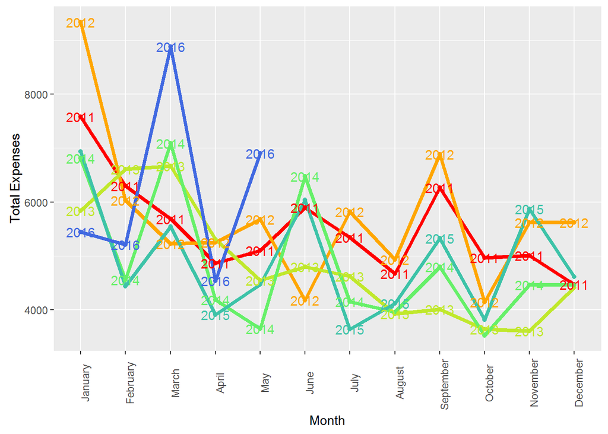

Looking at just expenses here. January and February of 2016 were actually lower than average, as well as April. March was very high but that was somewhat due to the fact that we spent $3000 on a sound system. Without that it would have in normal range. May was the highest expense May that we have had since 2011.

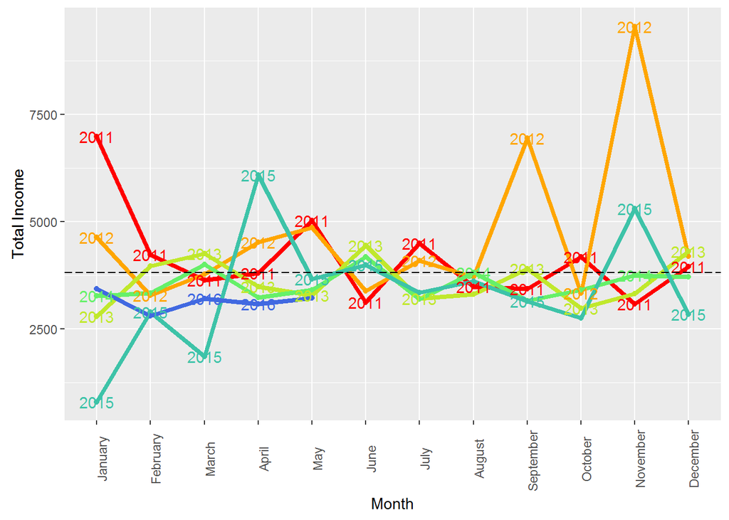

Our total income is lower than normal, which is represented by the dashed line, but has been relatively consistent.

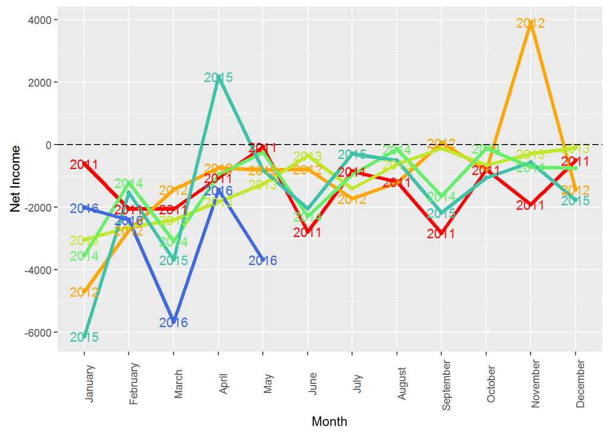

Net income is arrived at by taking the income and subtracting the expenses. 2016 has had two really bad months so far in terms of net income. But almost all months have a negative net income but it’s usually much smaller.

## Comparing Years

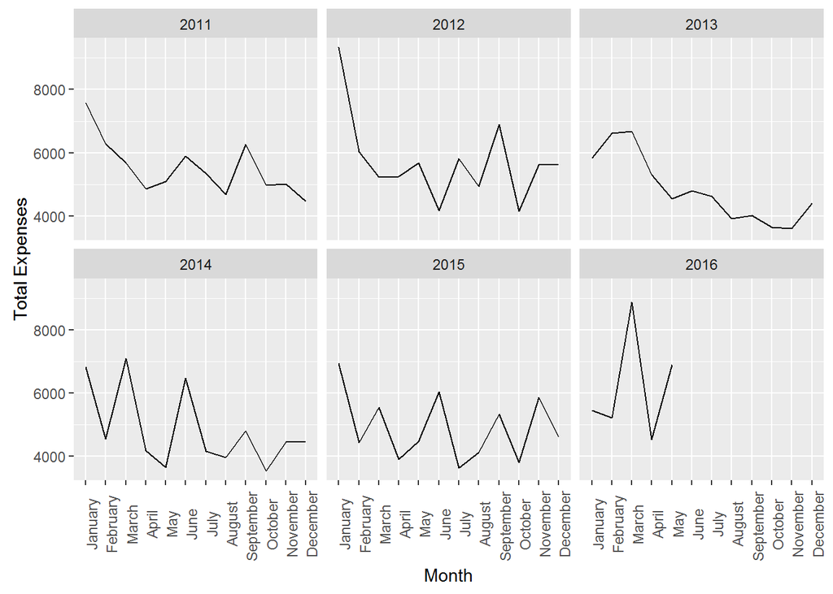

These facet wraps just give a sense of how each year looks on its own. Expenses are all over the place. They can jump up and down pretty dramatically from month to month. 2015 is a good example of that.

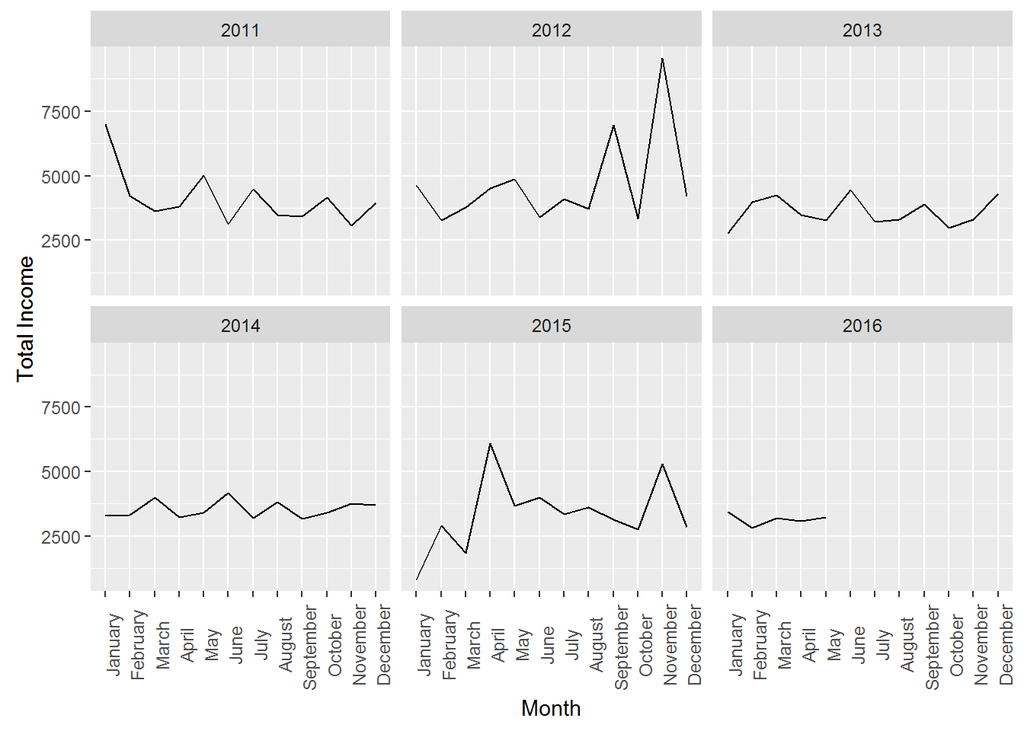

Total income is much more stable over time. 2013 and 2014 for instance were very even. 2016 looks to be relatively the same. It’s interesting to note that lost income in early 2015 because of weather seems to be made up for with a larger than normal April.

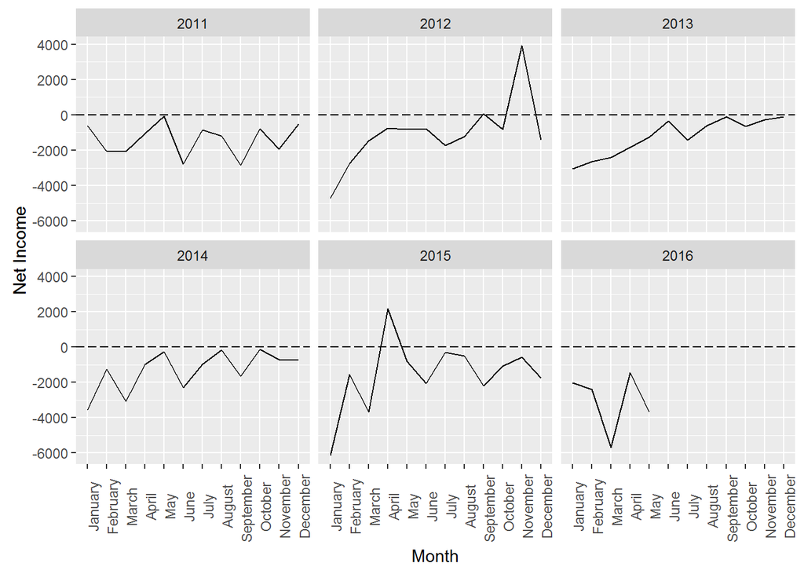

Looking at broad net income. Very few months over the last five+ years have had a positive net income. 2013 and 2014 look pretty similar with the trend moving toward zero near year end.

## Average Month?

[interactive chart not shown]

This chart is interactive, so you can mouse over each month to see the actual values of total income, total expenses, and net income.

Which months are bad? Which are good? The start of the year is historically bad because of expenses being higher. Income is very stable for the first nine months of the year then goes up in November. Looking month by month, the only month which has averaged a net positive has been November, but October and December are close.

Here’s a quick data table to show that decline in a different format.

|  | Date | Total Income | Total Expenses | Net Income |
| --- | --- | --- | --- | --- |
| 1 | 2011-01 | 6977 | 7581 | -604 |
| 2 | 2011-02 | 4233 | 6297 | -2064 |
| 3 | 2011-03 | 3634 | 5691 | -2057 |
| 4 | 2011-04 | 3802 | 4867 | -1065 |
| 5 | 2011-05 | 5029 | 5098 | -69 |
| 6 | 2011-06 | 3119 | 5902 | -2783 |
| 7 | 2011-07 | 4494 | 5345 | -851 |
| 8 | 2011-08 | 3485 | 4676 | -1191 |
| 9 | 2011-09 | 3437 | 6268 | -2831 |
| 10 | 2011-10 | 4176 | 4970 | -794 |

[output cut: 55 more lines]

## How Long Until the Money is Gone?

I wanted to project how long it would be for the church to completely run out of assets. I took the checking account balance as of June 1, 2016 and the amount in wills and bequest as of May 31, 2016 as a starting point. I did three pojection models. Each takes a look back at how much our deficit was and projects that forward. The green is the mean net income over 2015 and the first half of 2016. The orange line is 2013 to present. The blue line is 2011 to present.

[interactive chart not shown]

The green line is the most bleak scenario. Under this project the money runs out around March 2019. The other two scenarios put this event happening somewhere in the first half of 2020. These are just projections. They can’t take into account unforeseen expenses or income. This is just an educated guess, nothing more and nothing less.